# GEOG533 Lab 3

Dr. Qiusheng Wu

## Question 1

The **Cars93** dataset in the **MASS** package contains data from 93 cars on sale in the USA in 1993. Randomly select 40 cars as the training dataset and the remaining 53 cars as the test dataset. Save both datasets as csv files. Find out the number of **USA** and **non-USA** cars in the training dataset. (10 pt.)

### Solution 1

```r
library(MASS)
df <- Cars93
set.seed(100)
nrows <- nrow(df)
id <- 1:nrows
train.index <- sort(sample(1:nrows,40))
train.index
```

```
 [1]  6  8 11 12 15 16 18 22 23 24 27 28 29 31 32 36 39 40 42 43 47 51 52 53 55 58 59 61 62 65 67 71 72 73 74
[36] 78 83 86 89 93
```

```r
test.index <- id[-train.index]
test.index
```

```
 [1]  1  2  3  4  5  7  9 10 13 14 17 19 20 21 25 26 30 33 34 35 37 38 41 44 45 46 48 49 50 54 56 57 60 63 64
[36] 66 68 69 70 75 76 77 79 80 81 82 84 85 87 88 90 91 92
```

```r
train.df <- df[train.index,]
# library(knitr)
# kable(train.df)
test.df <- df[test.index,]
table(train.df$Origin)
```

```
    USA non-USA
     23      17
```

```r
if(!(require(DT))) install.packages("DT")
library(DT)
datatable(train.df,caption = "Training dataset",options = list(pageLength = 5, scrollX=TRUE))
```

|  | Manufacturer | Model | Type | Min.Price | Price | Max.Price | MPG.city | MPG.highway | AirBags | DriveTrain | Cylinders | EngineSize | Horsepower | RPM | Rev.per.mile | Man.trans.avail | Fuel.tank.capacity | Passengers | Length | Wheelbase | Width | Turn.circle | Rear.seat.room | Luggage.room | Weight | Origin | Make |
| --- | --- | --- | --- | --- | --- | --- | --- | --- | --- | --- | --- | --- | --- | --- | --- | --- | --- | --- | --- | --- | --- | --- | --- | --- | --- | --- | --- |
| 6 | Buick | Century | Midsize | 14.2 | 15.7 | 17.3 | 22 | 31 | Driver only | Front | 4 | 2.2 | 110 | 5200 | 2565 | No | 16.4 | 6 | 189 | 105 | 69 | 41 | 28 | 16 | 2880 | USA | Buick Century |
| 8 | Buick | Roadmaster | Large | 22.6 | 23.7 | 24.9 | 16 | 25 | Driver only | Rear | 6 | 5.7 | 180 | 4000 | 1320 | No | 23 | 6 | 216 | 116 | 78 | 45 | 30.5 | 21 | 4105 | USA | Buick Roadmaster |
| 11 | Cadillac | Seville | Midsize | 37.5 | 40.1 | 42.7 | 16 | 25 | Driver &amp; Passenger | Front | 8 | 4.6 | 295 | 6000 | 1985 | No | 20 | 5 | 204 | 111 | 74 | 44 | 31 | 14 | 3935 | USA | Cadillac Seville |
| 12 | Chevrolet | Cavalier | Compact | 8.5 | 13.4 | 18.3 | 25 | 36 | None | Front | 4 | 2.2 | 110 | 5200 | 2380 | Yes | 15.2 | 5 | 182 | 101 | 66 | 38 | 25 | 13 | 2490 | USA | Chevrolet Cavalier |
| 15 | Chevrolet | Lumina | Midsize | 13.4 | 15.9 | 18.4 | 21 | 29 | None | Front | 4 | 2.2 | 110 | 5200 | 2595 | No | 16.5 | 6 | 198 | 108 | 71 | 40 | 28.5 | 16 | 3195 | USA | Chevrolet Lumina |
| 16 | Chevrolet | Lumina_APV | Van | 14.7 | 16.3 | 18 | 18 | 23 | None | Front | 6 | 3.8 | 170 | 4800 | 1690 | No | 20 | 7 | 178 | 110 | 74 | 44 | 30.5 |  | 3715 | USA | Chevrolet Lumina_APV |
| 18 | Chevrolet | Caprice | Large | 18 | 18.8 | 19.6 | 17 | 26 | Driver only | Rear | 8 | 5 | 170 | 4200 | 1350 | No | 23 | 6 | 214 | 116 | 77 | 42 | 29.5 | 20 | 3910 | USA | Chevrolet Caprice |
| 22 | Chrysler | Imperial | Large | 29.5 | 29.5 | 29.5 | 20 | 26 | Driver only | Front | 6 | 3.3 | 147 | 4800 | 1785 | No | 16 | 6 | 203 | 110 | 69 | 44 | 36 | 17 | 3570 | USA | Chrysler Imperial |
| 23 | Dodge | Colt | Small | 7.9 | 9.2 | 10.6 | 29 | 33 | None | Front | 4 | 1.5 | 92 | 6000 | 3285 | Yes | 13.2 | 5 | 174 | 98 | 66 | 32 | 26.5 | 11 | 2270 | USA | Dodge Colt |
| 24 | Dodge | Shadow | Small | 8.4 | 11.3 | 14.2 | 23 | 29 | Driver only | Front | 4 | 2.2 | 93 | 4800 | 2595 | Yes | 14 | 5 | 172 | 97 | 67 | 38 | 26.5 | 13 | 2670 | USA | Dodge Shadow |

[output cut: 30 more lines]

```r
datatable(test.df,caption = "Test dataset",options = list(pageLength = 5, scrollX=TRUE))
```

|  | Manufacturer | Model | Type | Min.Price | Price | Max.Price | MPG.city | MPG.highway | AirBags | DriveTrain | Cylinders | EngineSize | Horsepower | RPM | Rev.per.mile | Man.trans.avail | Fuel.tank.capacity | Passengers | Length | Wheelbase | Width | Turn.circle | Rear.seat.room | Luggage.room | Weight | Origin | Make |
| --- | --- | --- | --- | --- | --- | --- | --- | --- | --- | --- | --- | --- | --- | --- | --- | --- | --- | --- | --- | --- | --- | --- | --- | --- | --- | --- | --- |
| 1 | Acura | Integra | Small | 12.9 | 15.9 | 18.8 | 25 | 31 | None | Front | 4 | 1.8 | 140 | 6300 | 2890 | Yes | 13.2 | 5 | 177 | 102 | 68 | 37 | 26.5 | 11 | 2705 | non-USA | Acura Integra |
| 2 | Acura | Legend | Midsize | 29.2 | 33.9 | 38.7 | 18 | 25 | Driver &amp; Passenger | Front | 6 | 3.2 | 200 | 5500 | 2335 | Yes | 18 | 5 | 195 | 115 | 71 | 38 | 30 | 15 | 3560 | non-USA | Acura Legend |
| 3 | Audi | 90 | Compact | 25.9 | 29.1 | 32.3 | 20 | 26 | Driver only | Front | 6 | 2.8 | 172 | 5500 | 2280 | Yes | 16.9 | 5 | 180 | 102 | 67 | 37 | 28 | 14 | 3375 | non-USA | Audi 90 |
| 4 | Audi | 100 | Midsize | 30.8 | 37.7 | 44.6 | 19 | 26 | Driver &amp; Passenger | Front | 6 | 2.8 | 172 | 5500 | 2535 | Yes | 21.1 | 6 | 193 | 106 | 70 | 37 | 31 | 17 | 3405 | non-USA | Audi 100 |
| 5 | BMW | 535i | Midsize | 23.7 | 30 | 36.2 | 22 | 30 | Driver only | Rear | 4 | 3.5 | 208 | 5700 | 2545 | Yes | 21.1 | 4 | 186 | 109 | 69 | 39 | 27 | 13 | 3640 | non-USA | BMW 535i |
| 7 | Buick | LeSabre | Large | 19.9 | 20.8 | 21.7 | 19 | 28 | Driver only | Front | 6 | 3.8 | 170 | 4800 | 1570 | No | 18 | 6 | 200 | 111 | 74 | 42 | 30.5 | 17 | 3470 | USA | Buick LeSabre |
| 9 | Buick | Riviera | Midsize | 26.3 | 26.3 | 26.3 | 19 | 27 | Driver only | Front | 6 | 3.8 | 170 | 4800 | 1690 | No | 18.8 | 5 | 198 | 108 | 73 | 41 | 26.5 | 14 | 3495 | USA | Buick Riviera |
| 10 | Cadillac | DeVille | Large | 33 | 34.7 | 36.3 | 16 | 25 | Driver only | Front | 8 | 4.9 | 200 | 4100 | 1510 | No | 18 | 6 | 206 | 114 | 73 | 43 | 35 | 18 | 3620 | USA | Cadillac DeVille |
| 13 | Chevrolet | Corsica | Compact | 11.4 | 11.4 | 11.4 | 25 | 34 | Driver only | Front | 4 | 2.2 | 110 | 5200 | 2665 | Yes | 15.6 | 5 | 184 | 103 | 68 | 39 | 26 | 14 | 2785 | USA | Chevrolet Corsica |
| 14 | Chevrolet | Camaro | Sporty | 13.4 | 15.1 | 16.8 | 19 | 28 | Driver &amp; Passenger | Rear | 6 | 3.4 | 160 | 4600 | 1805 | Yes | 15.5 | 4 | 193 | 101 | 74 | 43 | 25 | 13 | 3240 | USA | Chevrolet Camaro |

[output cut: 43 more lines]

### Solution 2

```r
if(!require(dplyr)) install.packages("dplyr")
library(dplyr)
library(MASS)
df <- Cars93
df$id <- 1:nrow(df)
train.df <- sample_n(df,size = 40)
test.df <- anti_join(df,train.df,by="id")
# Display the data
if(!(require(DT))) install.packages("DT")
library(DT)
datatable(train.df,caption = "Training dataset",options = list(pageLength = 5, scrollX=TRUE))
```

|  | Manufacturer | Model | Type | Min.Price | Price | Max.Price | MPG.city | MPG.highway | AirBags | DriveTrain | Cylinders | EngineSize | Horsepower | RPM | Rev.per.mile | Man.trans.avail | Fuel.tank.capacity | Passengers | Length | Wheelbase | Width | Turn.circle | Rear.seat.room | Luggage.room | Weight | Origin | Make | id |
| --- | --- | --- | --- | --- | --- | --- | --- | --- | --- | --- | --- | --- | --- | --- | --- | --- | --- | --- | --- | --- | --- | --- | --- | --- | --- | --- | --- | --- |
| 31 | Ford | Festiva | Small | 6.9 | 7.4 | 7.9 | 31 | 33 | None | Front | 4 | 1.3 | 63 | 5000 | 3150 | Yes | 10 | 4 | 141 | 90 | 63 | 33 | 26 | 12 | 1845 | USA | Ford Festiva | 31 |
| 80 | Subaru | Justy | Small | 7.3 | 8.4 | 9.5 | 33 | 37 | None | 4WD | 3 | 1.2 | 73 | 5600 | 2875 | Yes | 9.2 | 4 | 146 | 90 | 60 | 32 | 23.5 | 10 | 2045 | non-USA | Subaru Justy | 80 |
| 71 | Oldsmobile | Eighty-Eight | Large | 19.5 | 20.7 | 21.9 | 19 | 28 | Driver only | Front | 6 | 3.8 | 170 | 4800 | 1570 | No | 18 | 6 | 201 | 111 | 74 | 42 | 31.5 | 17 | 3470 | USA | Oldsmobile Eighty-Eight | 71 |
| 75 | Pontiac | Firebird | Sporty | 14 | 17.7 | 21.4 | 19 | 28 | Driver &amp; Passenger | Rear | 6 | 3.4 | 160 | 4600 | 1805 | Yes | 15.5 | 4 | 196 | 101 | 75 | 43 | 25 | 13 | 3240 | USA | Pontiac Firebird | 75 |
| 54 | Mazda | Protege | Small | 10.9 | 11.6 | 12.3 | 28 | 36 | None | Front | 4 | 1.8 | 103 | 5500 | 2220 | Yes | 14.5 | 5 | 172 | 98 | 66 | 36 | 26.5 | 13 | 2440 | non-USA | Mazda Protege | 54 |
| 44 | Hyundai | Excel | Small | 6.8 | 8 | 9.2 | 29 | 33 | None | Front | 4 | 1.5 | 81 | 5500 | 2710 | Yes | 11.9 | 5 | 168 | 94 | 63 | 35 | 26 | 11 | 2345 | non-USA | Hyundai Excel | 44 |
| 68 | Oldsmobile | Achieva | Compact | 13 | 13.5 | 14 | 24 | 31 | None | Front | 4 | 2.3 | 155 | 6000 | 2380 | No | 15.2 | 5 | 188 | 103 | 67 | 39 | 28 | 14 | 2910 | USA | Oldsmobile Achieva | 68 |
| 77 | Pontiac | Bonneville | Large | 19.4 | 24.4 | 29.4 | 19 | 28 | Driver &amp; Passenger | Front | 6 | 3.8 | 170 | 4800 | 1565 | No | 18 | 6 | 177 | 111 | 74 | 43 | 30.5 | 18 | 3495 | USA | Pontiac Bonneville | 77 |
| 18 | Chevrolet | Caprice | Large | 18 | 18.8 | 19.6 | 17 | 26 | Driver only | Rear | 8 | 5 | 170 | 4200 | 1350 | No | 23 | 6 | 214 | 116 | 77 | 42 | 29.5 | 20 | 3910 | USA | Chevrolet Caprice | 18 |
| 26 | Dodge | Caravan | Van | 13.6 | 19 | 24.4 | 17 | 21 | Driver only | 4WD | 6 | 3 | 142 | 5000 | 1970 | No | 20 | 7 | 175 | 112 | 72 | 42 | 26.5 |  | 3705 | USA | Dodge Caravan | 26 |

[output cut: 30 more lines]

```r
datatable(test.df,caption = "Test dataset",options = list(pageLength = 5, scrollX=TRUE))
```

|  | Manufacturer | Model | Type | Min.Price | Price | Max.Price | MPG.city | MPG.highway | AirBags | DriveTrain | Cylinders | EngineSize | Horsepower | RPM | Rev.per.mile | Man.trans.avail | Fuel.tank.capacity | Passengers | Length | Wheelbase | Width | Turn.circle | Rear.seat.room | Luggage.room | Weight | Origin | Make | id |
| --- | --- | --- | --- | --- | --- | --- | --- | --- | --- | --- | --- | --- | --- | --- | --- | --- | --- | --- | --- | --- | --- | --- | --- | --- | --- | --- | --- | --- |
| 1 | Acura | Integra | Small | 12.9 | 15.9 | 18.8 | 25 | 31 | None | Front | 4 | 1.8 | 140 | 6300 | 2890 | Yes | 13.2 | 5 | 177 | 102 | 68 | 37 | 26.5 | 11 | 2705 | non-USA | Acura Integra | 1 |
| 2 | Acura | Legend | Midsize | 29.2 | 33.9 | 38.7 | 18 | 25 | Driver &amp; Passenger | Front | 6 | 3.2 | 200 | 5500 | 2335 | Yes | 18 | 5 | 195 | 115 | 71 | 38 | 30 | 15 | 3560 | non-USA | Acura Legend | 2 |
| 3 | Audi | 90 | Compact | 25.9 | 29.1 | 32.3 | 20 | 26 | Driver only | Front | 6 | 2.8 | 172 | 5500 | 2280 | Yes | 16.9 | 5 | 180 | 102 | 67 | 37 | 28 | 14 | 3375 | non-USA | Audi 90 | 3 |
| 4 | Audi | 100 | Midsize | 30.8 | 37.7 | 44.6 | 19 | 26 | Driver &amp; Passenger | Front | 6 | 2.8 | 172 | 5500 | 2535 | Yes | 21.1 | 6 | 193 | 106 | 70 | 37 | 31 | 17 | 3405 | non-USA | Audi 100 | 4 |
| 5 | Buick | Century | Midsize | 14.2 | 15.7 | 17.3 | 22 | 31 | Driver only | Front | 4 | 2.2 | 110 | 5200 | 2565 | No | 16.4 | 6 | 189 | 105 | 69 | 41 | 28 | 16 | 2880 | USA | Buick Century | 6 |
| 6 | Buick | LeSabre | Large | 19.9 | 20.8 | 21.7 | 19 | 28 | Driver only | Front | 6 | 3.8 | 170 | 4800 | 1570 | No | 18 | 6 | 200 | 111 | 74 | 42 | 30.5 | 17 | 3470 | USA | Buick LeSabre | 7 |
| 7 | Buick | Roadmaster | Large | 22.6 | 23.7 | 24.9 | 16 | 25 | Driver only | Rear | 6 | 5.7 | 180 | 4000 | 1320 | No | 23 | 6 | 216 | 116 | 78 | 45 | 30.5 | 21 | 4105 | USA | Buick Roadmaster | 8 |
| 8 | Buick | Riviera | Midsize | 26.3 | 26.3 | 26.3 | 19 | 27 | Driver only | Front | 6 | 3.8 | 170 | 4800 | 1690 | No | 18.8 | 5 | 198 | 108 | 73 | 41 | 26.5 | 14 | 3495 | USA | Buick Riviera | 9 |
| 9 | Cadillac | Seville | Midsize | 37.5 | 40.1 | 42.7 | 16 | 25 | Driver &amp; Passenger | Front | 8 | 4.6 | 295 | 6000 | 1985 | No | 20 | 5 | 204 | 111 | 74 | 44 | 31 | 14 | 3935 | USA | Cadillac Seville | 11 |
| 10 | Chevrolet | Cavalier | Compact | 8.5 | 13.4 | 18.3 | 25 | 36 | None | Front | 4 | 2.2 | 110 | 5200 | 2380 | Yes | 15.2 | 5 | 182 | 101 | 66 | 38 | 25 | 13 | 2490 | USA | Chevrolet Cavalier | 12 |

[output cut: 43 more lines]

## Question 2

Assume that the probabilities of boy and girl births are 0.515 and 0.485, respectively. Use the **sample()** function to simulate 10 births and print out the result. How many boys and girls do you get out of 10 births? Then simulate 10,000 births. How many boys and girls do you get out of 10,000 births? (10 pt.)

```r
births <- sample(c("boy","girl"),size = 10,replace = TRUE,prob = c(0.515,0.485))
births
```

```
 [1] "boy"  "girl" "girl" "girl" "boy"  "girl" "girl" "boy"  "boy"  "girl"
```

```r
table(births)
```

```
births
 boy girl
   4    6
```

```r
births <- sample(c("boy","girl"),size = 10000,replace = TRUE,prob = c(0.515,0.485))
table(births)
```

```
births
 boy girl
5188 4812
```

## Question 3

Assume that the probabilities of boy and girl births are 0.515 and 0.485, respectively. What’s the probability of having exactly 3 boys out of 10 births? What’s the probability of having 8 or more boys out of 10 births? Plot both the density function and cumulative probability function of the number of boy births out of 10. (15 pt.)

```r
prob1 <- dbinom(3,size = 10,prob = 0.515)
prob1
```

```
[1] 0.1034654
```

```r
prob2 <- 1 - pbinom(7,size = 10,prob = 0.515)
prob2
```

```
[1] 0.06605068
```

```r
pbinom(7,size = 10,prob = 0.515,lower.tail = FALSE)
```

```
[1] 0.06605068
```

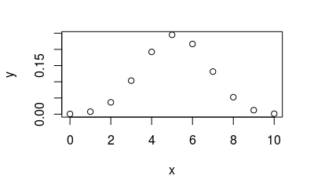

```r
n <- 10
x <- 0:n
y <- dbinom(x,size = n,prob = 0.515)
plot(x,y)
```

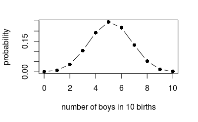

```r
plot(x,y,type="b",pch=16,col="black", xlab="number of boys in 10 births",ylab="probability")
```

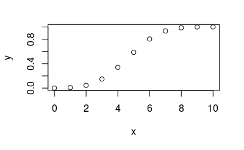

```r
y <- pbinom(x,size = n,prob = 0.515)
plot(x,y)
```

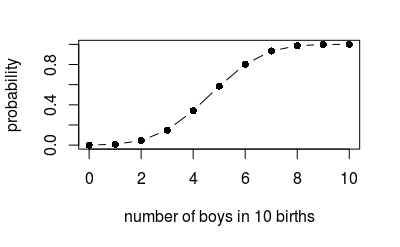

```r
plot(x,y,type="b",pch=16,col="black", xlab="number of boys in 10 births",ylab="probability")
```

## Question 4

If cars arrive randomly at a traffic light at the rate of five every ten seconds. What the probability that exactly four cars arrive in the next ten seconds? What’s the probability that more than five cars arrive in the next ten seconds? Plot the density function of 0-20 cars arriving in the next ten seconds. (15 pt.)

```r
dpois(4,lambda = 5)
```

```
[1] 0.1754674
```

```r
1 - ppois(5,lambda = 5)
```

```
[1] 0.3840393
```

```r
ppois(5,lambda = 5,lower.tail = FALSE)
```

```
[1] 0.3840393
```

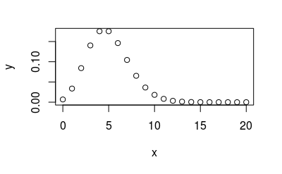

```r
n <- 20
x <- 0:n
y <- dpois(x,lambda = 5)
plot(x,y)
```

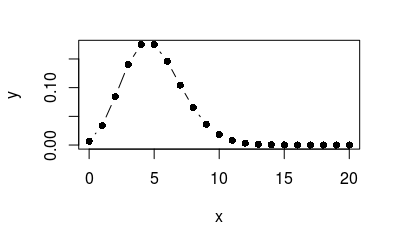

```r
plot(x,y,type = "b",pch = 16,col="black")
```